# Problemset: Time

# 1 Setup

```r
library(tidyverse)
library(lubridate)
library(ggrepel)
theme_set(theme_bw())
```

## 1.1 Data

We use bakery sales data provided by [Meteolytix](https://meteolytix.de/) for some unknown bakery of the Kiel region. Additionally, we use weather data from Deutscher Wetterdienst (DWD).

```r
sales <- read_csv("data/sales.csv")        # Bakery sales
weather <- read_csv("data/weather.csv")    # Weather data
df <- sales %>% left_join(weather, by = "date")
```

## 1.2 Feature engineering

```r
df <- df %>%
  mutate(
    wday = lubridate::wday(date, label=TRUE, abbr=FALSE, week_start = 1),
    month = month(date, label=TRUE, abbr = FALSE),
    year = year(date),
    dayofyear = yday(date))
```

The product types in the data are represented with anonymous numbers (1-6). Part of your task is to infer which number corresponds to which actual type: bread, rolls, cakes, drinks, patisserie, snacks.

Visualize the full time series of total daily sales. Which trends or patterns do you see?

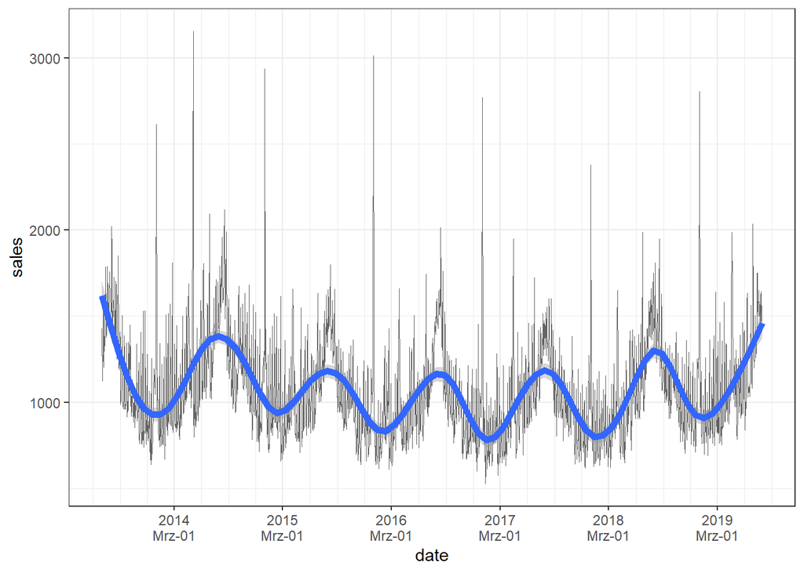

```r
df %>%
  group_by(date) %>%
  summarise(sales = sum(sales)) %>%
  ggplot(aes(date, sales)) +
  geom_line(size=0.1, alpha=0.6) +
  geom_smooth(formula=y ~ s(x, bs='cs', k=20), size=2) +   # Smoothness paramter: k
  scale_x_date(
    date_breaks = "12 months",        # Distance between labeled breaks
    date_minor_breaks = "3 month",    # Distance between grid lines
    date_labels = "%Y\n%b-%d"         # Date labels format
  )
```

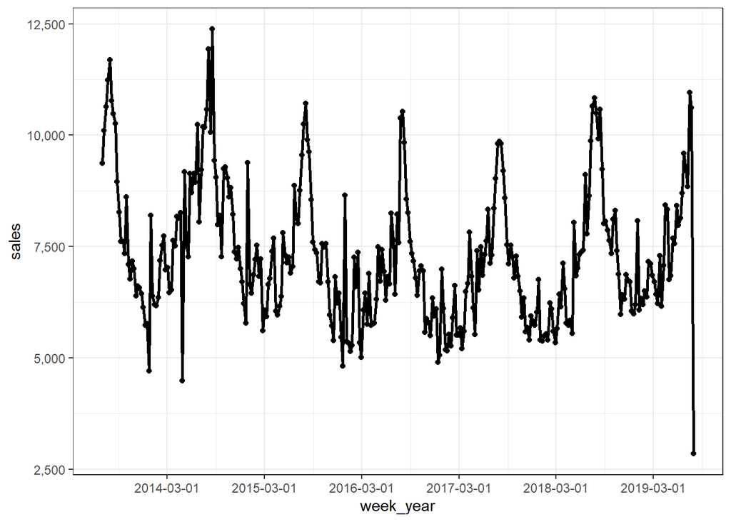

```r
df %>%
  mutate(week_year = lubridate::floor_date(date, unit="weeks", week_start=1)) %>%
  group_by(week_year) %>%
  summarise(sales = sum(sales)) %>%
  ggplot(aes(week_year, sales)) +
  geom_line(size=1) + geom_point() +
  scale_x_date(
    date_breaks = "12 months",          # Distance between labeled breaks
    date_minor_breaks = "6 month",     # Distance between grid lines
    date_labels = "%Y-%m-%d"         # Date labels format
  ) +
  scale_y_continuous(labels=scales::comma)
```

Visualize the full time series of daily sales per product type. Which product-specific patterns do you perceive?

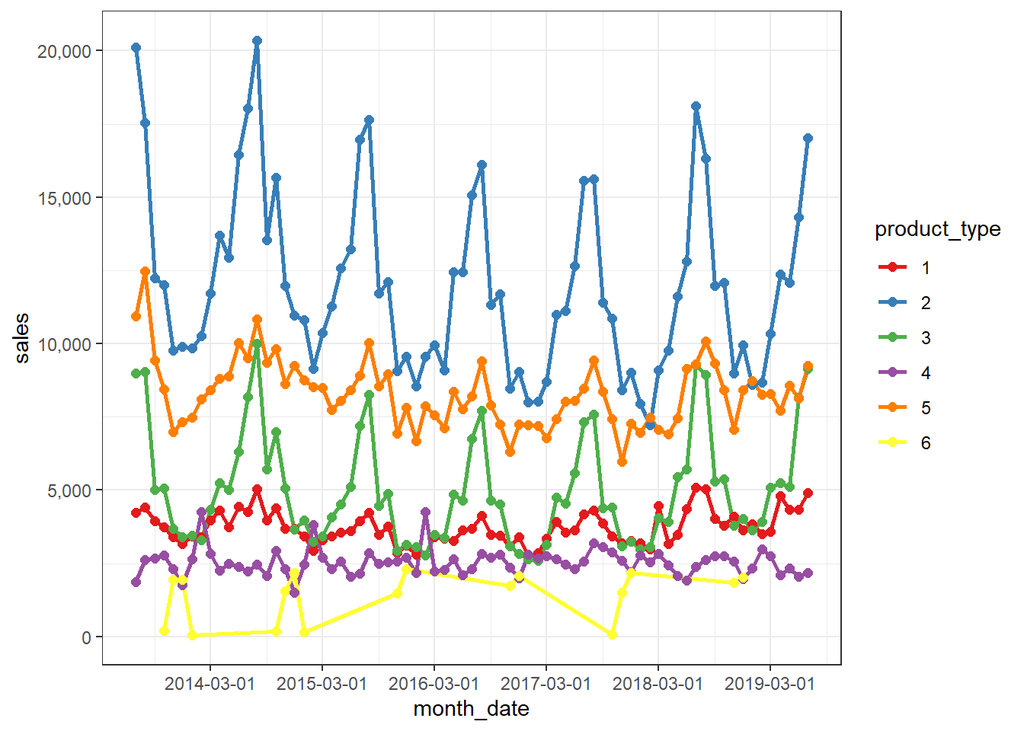

```r
df %>%
  mutate(month_date = lubridate::floor_date(date, unit="months")) %>%
  group_by(month_date, product_type = factor(product_type)) %>%
  summarise(sales = sum(sales)) %>%
  ggplot(aes(month_date, sales, color = product_type)) +
  geom_line(size = 1) + geom_point(size = 2) +
  #geom_smooth(size=1, span=0.3, se=FALSE) +
  scale_x_date(
    date_breaks = "12 months",          # Distance between labeled breaks
    date_minor_breaks = "6 month",     # Distance between grid lines
    date_labels = "%Y-%m-%d"         # Date labels format
  ) +
  scale_y_continuous(labels=scales::comma) +
  scale_color_brewer(palette = "Set1")
```

Zoom in on a particular year to visualize the intra-year patterns. Which patterns do you see?

```r
df %>% mutate(holiday = ifelse(month=='Dezember' & day(date)==31, 1, 0))
```

| date | product_type | sales | precipitation | sunhours | temperature | wday | month | year | dayofyear | holiday |
| --- | --- | --- | --- | --- | --- | --- | --- | --- | --- | --- |
| 2013-07-01 | 1 | 148.82835 | 0.3 | 6.000 | 15.6 | Montag | Juli | 2013 | 182 | 0 |
| 2013-07-02 | 1 | 159.79376 | 0.1 | 8.500 | 15.1 | Dienstag | Juli | 2013 | 183 | 0 |
| 2013-07-03 | 1 | 111.88559 | 10.2 | 2.000 | 18.0 | Mittwoch | Juli | 2013 | 184 | 0 |
| 2013-07-04 | 1 | 168.86494 | 0.0 | 0.200 | 17.2 | Donnerstag | Juli | 2013 | 185 | 0 |
| 2013-07-05 | 1 | 171.28075 | 0.0 | 8.100 | 16.9 | Freitag | Juli | 2013 | 186 | 0 |
| 2013-07-06 | 1 | 174.55236 | 0.0 | 16.000 | 15.3 | Samstag | Juli | 2013 | 187 | 0 |
| 2013-07-07 | 1 | 92.63776 | 0.0 | 15.100 | 17.2 | Sonntag | Juli | 2013 | 188 | 0 |
| 2013-07-08 | 1 | 135.50024 | 0.0 | 14.500 | 18.4 | Montag | Juli | 2013 | 189 | 0 |
| 2013-07-09 | 1 | 136.04838 | 0.0 | 14.500 | 18.6 | Dienstag | Juli | 2013 | 190 | 0 |
| 2013-07-10 | 1 | 135.13231 | 0.0 | 11.400 | 16.8 | Mittwoch | Juli | 2013 | 191 | 0 |

[output cut: 9990 more lines]

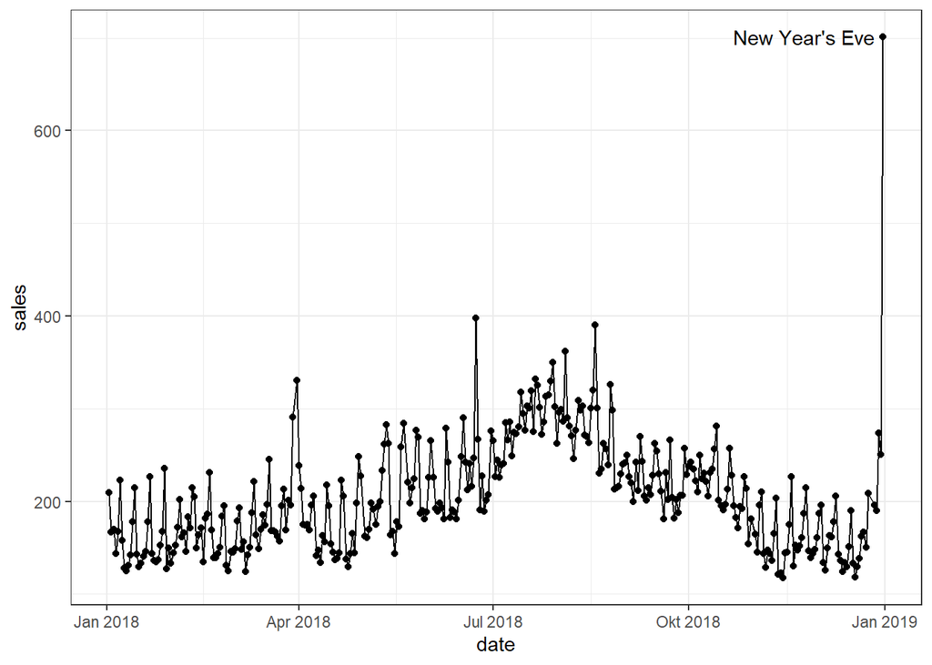

```r
df %>%
  filter(year==2018) %>%
  mutate(holiday = ifelse(month=="Dezember" & day(date)==31, "New Year's Eve", NA)) %>%
  group_by(date, holiday) %>%
  summarise(sales = mean(sales)) %>%
  ggplot(aes(date, sales)) +
  geom_line() + geom_point() +
  geom_text_repel(aes(label = holiday))
```

Visualize intra-week sales patterns. On which day does the bakery sell the most/least?

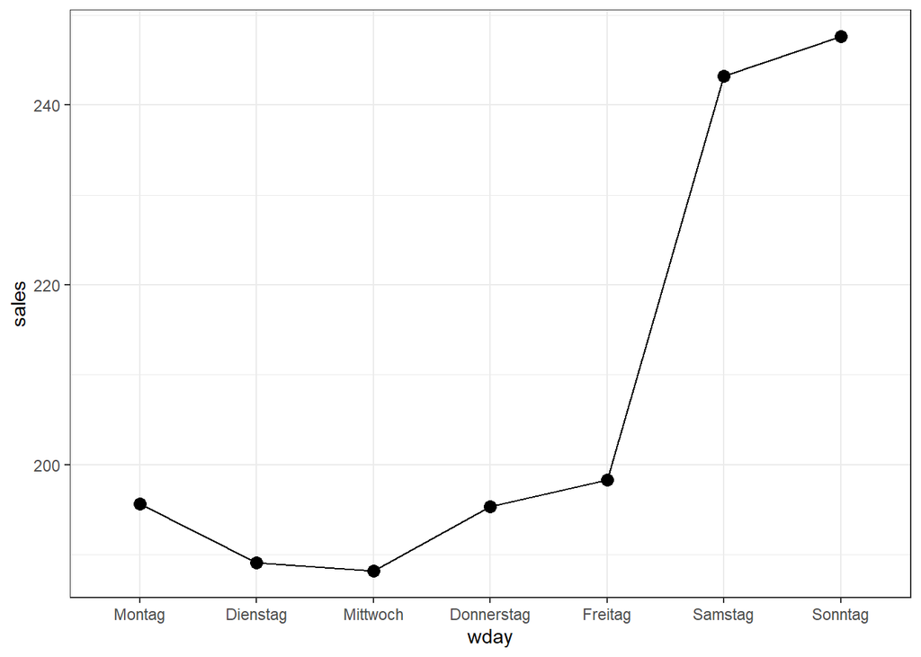

```r
df %>%
  group_by(wday) %>%
  summarise(sales = mean(sales)) %>%
  ggplot(aes(x=wday, y=sales)) +
  geom_point(size = 3) + geom_line(aes(group = 1)) +
  scale_color_brewer(palette = "Set1")
```

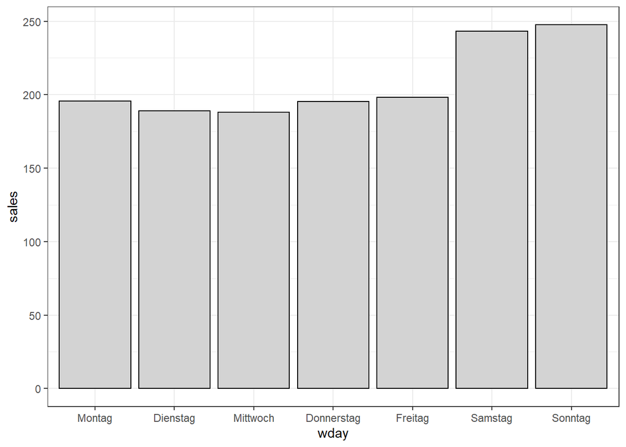

```r
df %>%
  group_by(wday) %>%
  summarise(sales = mean(sales)) %>%
  ggplot(aes(x=wday, y=sales)) +
  geom_col(fill = 'lightgrey', col = "black") +
  scale_color_brewer(palette = "Set1")
```

Visualize the average daily sales per weekday and product type? Which product-specific patterns do you see?

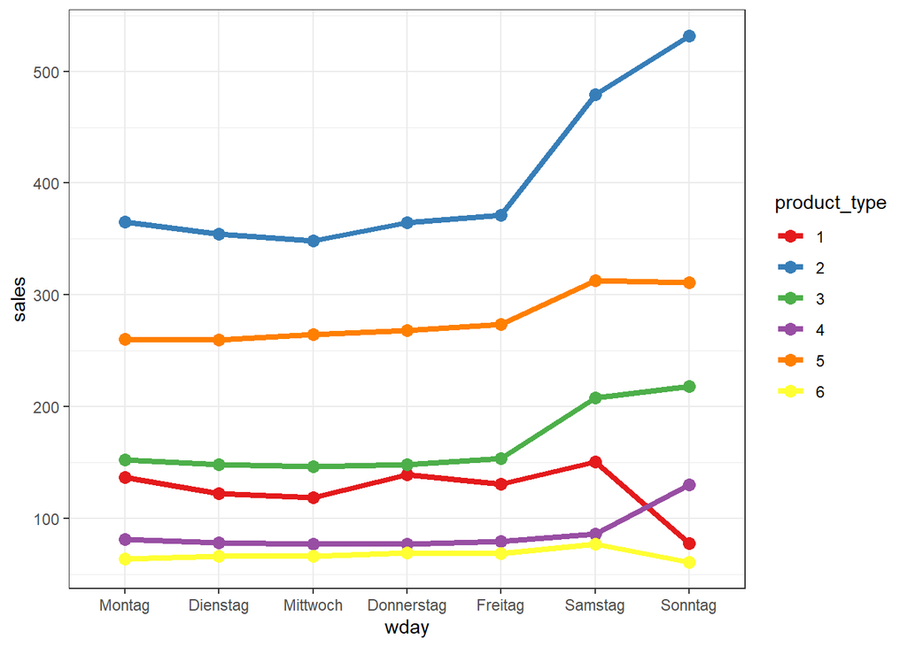

```r
df %>%
  group_by(wday, product_type = factor(product_type)) %>%
  summarise(sales = mean(sales)) %>%
  ggplot(aes(x=wday, y=sales, color=product_type)) +
  geom_point(size = 3) +
  geom_line(aes(group=product_type), size = 1.5) +
  scale_color_brewer(palette = "Set1")
```

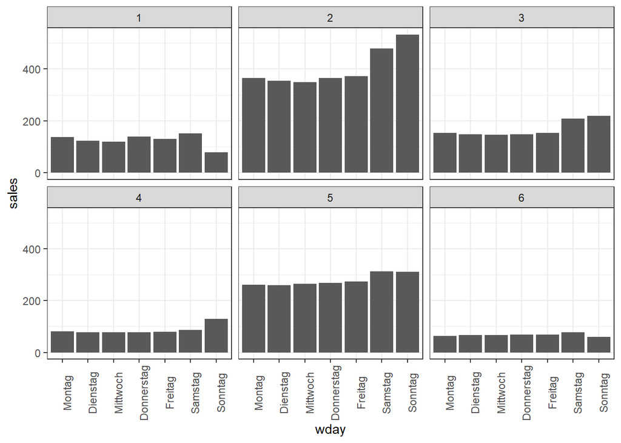

```r
df %>%
  group_by(wday, product_type = factor(product_type)) %>%
  summarise(sales = mean(sales)) %>%
  ggplot(aes(x=wday, y=sales)) +
  geom_col() +
  scale_color_brewer(palette = "Set1") +
  facet_wrap(vars(product_type)) +
  theme(axis.text.x = element_text(angle = 90))
```

Is there a relationship between weather features (sunshine, temperature, rain) and sales?

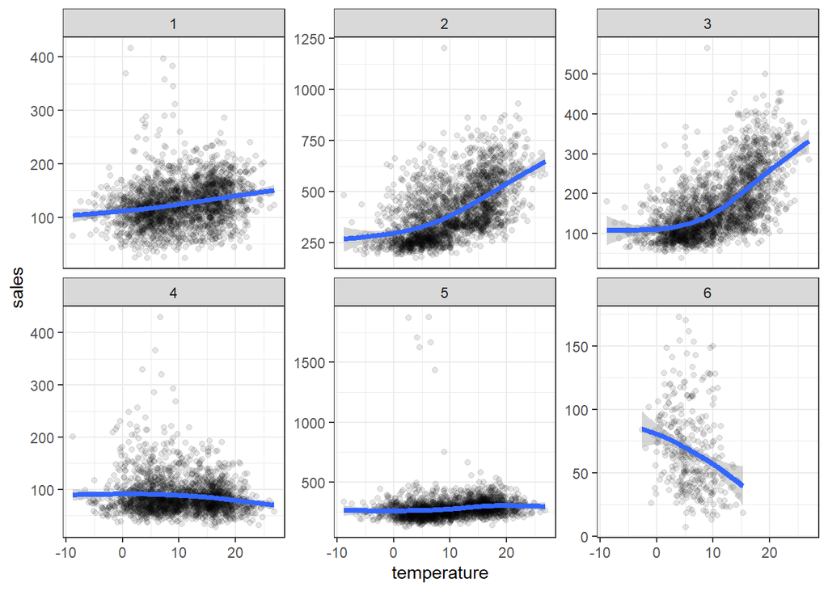

```r
df %>%
  ggplot(aes(x = temperature, y = sales)) +
  geom_point(alpha = 0.1) + geom_smooth(size = 1.5) +
  facet_wrap(vars(product_type), scales = "free_y")
```

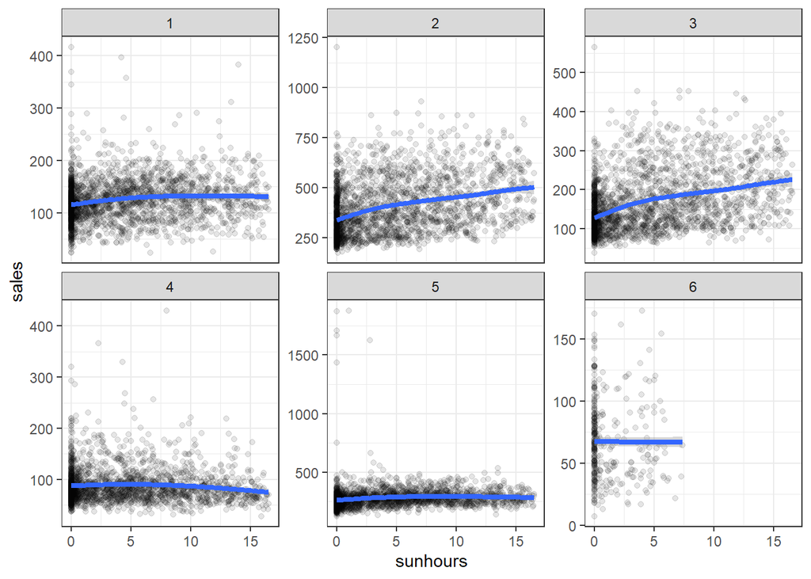

```r
df %>%
  ggplot(aes(x = sunhours, y = sales)) +
  geom_point(alpha = 0.1) + geom_smooth(size = 1.5) +
  facet_wrap(vars(product_type), scales = "free_y")
```

Can you predict sales based on time- and wheather related features?